# A forest of Random Barbells

Alexander Spray

Sunday, June 05, 2016

We’re working on a weight lifting excercise dataset, with samples from 5 users using exhibiting each “class” of activity (defined as either correctly executing the excercise, classe=A, or some vaiation on incorrectly executing the excercise, classe!=A) of accelerometer data from various motion sensing devices. The aim is to create a classifier which accurately identifies in what class the activity is given the motion sensor data.

First off we notice that there are several variables with NAs in the training data.

```r
trainDat<-read.csv("C:\\Users\\Alexander\\Downloads\\pml-training.csv")
testDat<-read.csv("C:\\Users\\Alexander\\Downloads\\pml-testing.csv")
nrow(trainDat)-nrow(trainDat[which(complete.cases(trainDat)),])
```

```
## [1] 19216
```

But, there’s no real point to keep any variables (aside from out outcome) that aren’t in our test dataset, which solves our problem since many of the variables are NA only in the test. Beyond this we can note that the fist several variables are broadly categorical (names, timestamps etc). And can be removed (indeed, the first plot shows that the outcome is sorted by rownum, if we keep X we will certainly overfit)

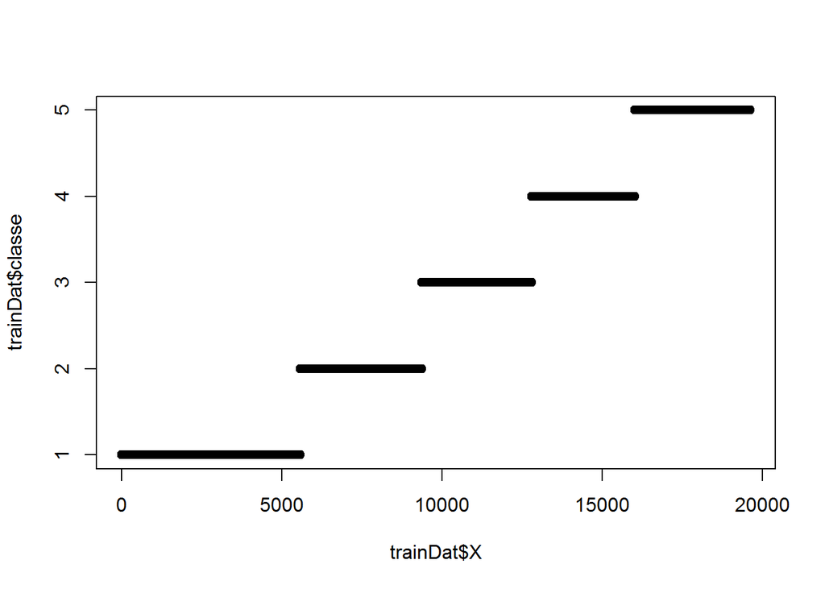

```r
plot(trainDat$X,trainDat$classe)
```

```r
head(names(trainDat),10)
```

```
##  [1] "X"                    "user_name"            "raw_timestamp_part_1"
##  [4] "raw_timestamp_part_2" "cvtd_timestamp"       "new_window"
##  [7] "num_window"           "roll_belt"            "pitch_belt"
## [10] "yaw_belt"
```

We are left with 53 predictors, which would seem to be too many to plot effectively. Instead, we will attempt to restrict our input columns via variable importance as defined by a naive default random forest on the dataset

Below we can see the confusion matrix of our Trained Model (first pass with all variables). And the order and importance of the variables in the dataset. For the final model and below 8 fold cross validation, we will use only the 20 most important variables.

```
## Confusion Matrix and Statistics
##
##           Reference
## Prediction    A    B    C    D    E
##          A 5577   12    0    0    0
##          B    3 3781    9    0    0
##          C    0    4 3410   19    2
##          D    0    0    3 3195    3
##          E    0    0    0    2 3602
##
## Overall Statistics
##
##                Accuracy : 0.9971
##                  95% CI : (0.9962, 0.9978)
##     No Information Rate : 0.2844
##     P-Value [Acc > NIR] : < 2.2e-16
##
##                   Kappa : 0.9963
##  Mcnemar's Test P-Value : NA
##
## Statistics by Class:
##
##                      Class: A Class: B Class: C Class: D Class: E
## Sensitivity            0.9995   0.9958   0.9965   0.9935   0.9986
## Specificity            0.9991   0.9992   0.9985   0.9996   0.9999
## Pos Pred Value         0.9979   0.9968   0.9927   0.9981   0.9994
## Neg Pred Value         0.9998   0.9990   0.9993   0.9987   0.9997
## Prevalence             0.2844   0.1935   0.1744   0.1639   0.1838
## Detection Rate         0.2842   0.1927   0.1738   0.1628   0.1836
## Detection Prevalence   0.2848   0.1933   0.1751   0.1631   0.1837
## Balanced Accuracy      0.9993   0.9975   0.9975   0.9966   0.9992
```

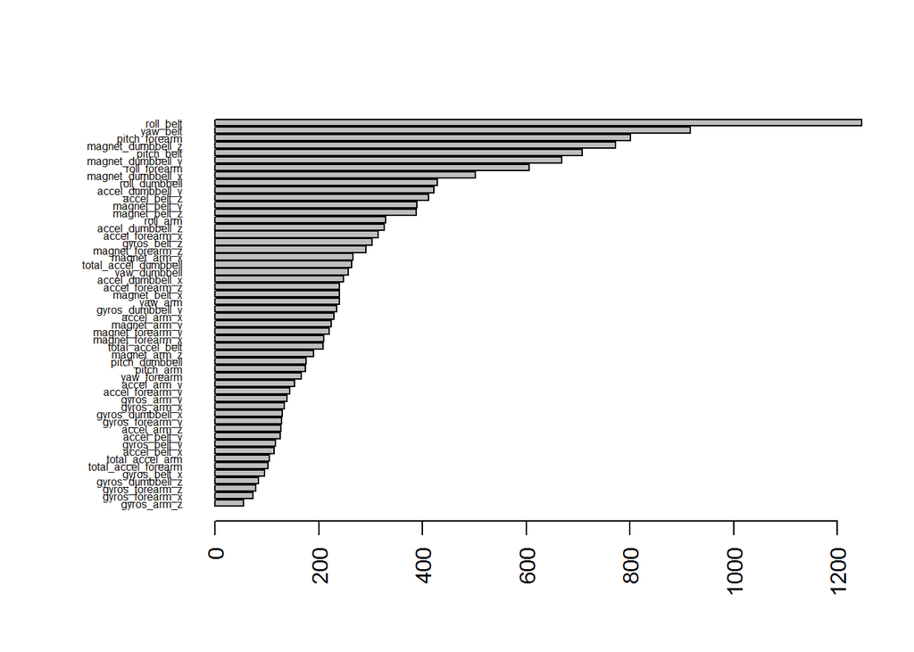

These top 20 variables have the highest variable importance per this random forest. We will procede with 8 fold cross validation to examine the out of sample error using a random forest trained from only these 20 variables. Leave one out would take a very long time with this large a dataset, especially when fitting a random forest. (in sample accuracy appears very high. Let’s hope we’ve avoided overfit). Here I’ve set mtry = 10, and ntrees=100 based generally on some tiny grid search. But the default specification works well as well.

```r
#let's go 8 fold
ptm<-proc.time()
correctList<-c()
for(i in 1:8){
    myVars<-c("user_name","classe",topVars)
    #take the accuracy
    #inum<-nrow(trainDat)/8
    #mySeq<-c(((i-1)*inum+1):((i)*inum))
    #randomSamples?
    mySeq<-sample(trainDat$X,nrow(trainDat)/8)
    myTest<-trainDat[mySeq,which(names(trainDat)%in%myVars)]
    myTrain<-trainDat[-mySeq,which(names(trainDat)%in%myVars)]
    myModel<-randomForest(classe~.,data=myTrain,mtry=10,ntree=100)
    myPred<-predict(myModel,newdata=myTest[,1:(ncol(myTest)-1)])
    correctList<-c(correctList,confusionMatrix(myPred,myTest$classe)$overall[[1]])
}
correctList
```

```
## [1] 0.9942904 0.9938825 0.9934747 0.9906199 0.9951060 0.9946982 0.9922512
## [8] 0.9922512
```

Our mean expected accuracy:

```
## [1] "Mean:"
```

```
## [1] 0.9933218
```

```
## [1] "Standard Deviation"
```

```
## [1] 0.001509327
```

That’s all she wrote. As has been stated in the class, randomForests is one of the best out of the box classifiers. It seems at least to have lived up to the hype.